# Yeast species pooled RNA-seq

Arnaud N’Guessan

2025-08-13

This report summarizes the yeast subphylum pooled RNA-seq analysis.The reference genome files come from the Opulente et al. (2024) paper and can be downloaded at https://plus-figshare-com.myaccess.library.utoronto.ca/collections/Genomic_and_ecological_factors_shaping_specialism_and_generalism_across_an_entire_subphylum/6714042/2.

21 species spanning the yeast subphylum were selected based on clade identity and were randomly assigned to a mixture of 7 species:

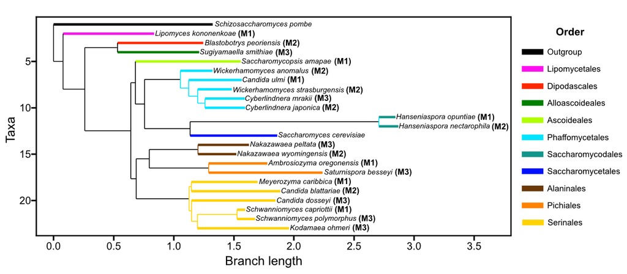

Phylogenetic tree of the 21 species included in this experiment

## Pre-processing

The raw data show evidence of sequencing errors and noise that can be solved through trimming and overrepresented sequence analysis:

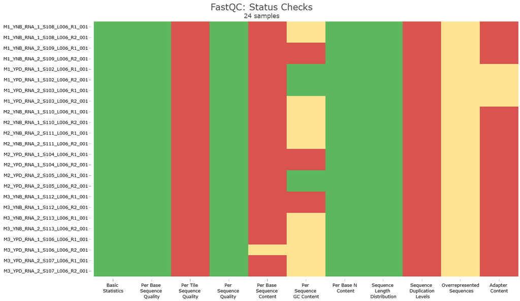

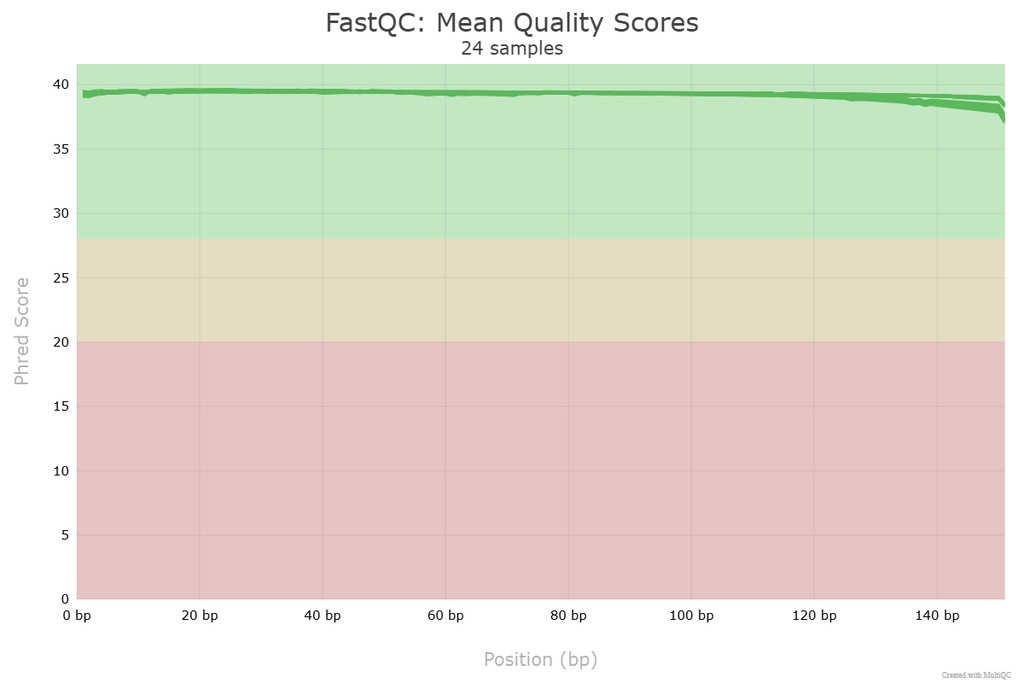

Before mapping the RNA-seq reads to the reference genomes, let’s “clean” the raw reads with fastp (quality profiling, read filtering, read pruning, adapter trimming, polyG/polyX tail trimming, overrepresented sequence analysis and removal, etc): https://github.com/OpenGene/fastp?tab=readme-ov-file#overrepresented-sequence-analysis.

```r
# fastp -i raw_RNA_seq_pools/{}_R1_001.fastq.gz \
#       -I raw_RNA_seq_pools/{}_R2_001.fastq.gz \
#       -o fastp_preprocessed/{}_trimmed_1.fastq.gz \
#       -O fastp_preprocessed/{}_trimmed_2.fastq.gz \
#       -h fastp_preprocessed/fastp_{}.html \
#       -j fastp_preprocessed/fastp_{}.json \
#       -l 151 \
#       --trim_poly_g \
#       --trim_poly_a \
#       --cut_front \
#       --cut_front_mean_quality 20 \
#       --cut_tail \
#       --cut_tail_mean_quality 20 \
#       --detect_adapter_for_pe \
#       --overrepresentation_analysis \
#       --thread 2 \
```

After running fastp on the raw data, adapter were removed and base calling improved in general:

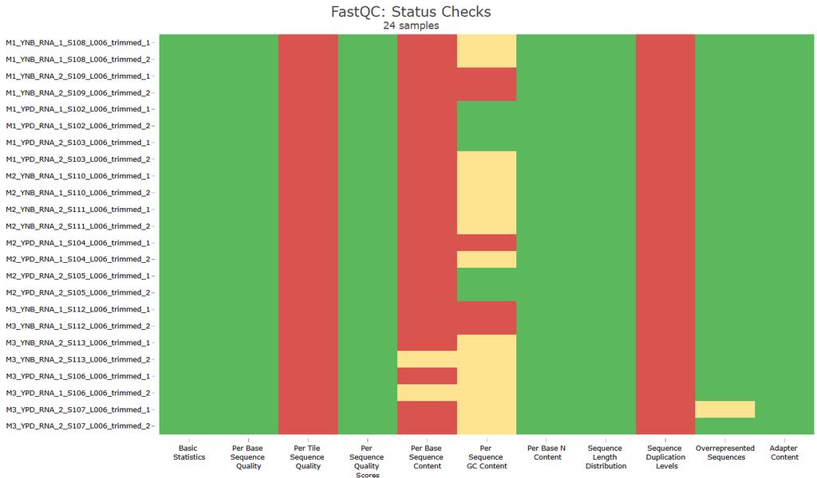

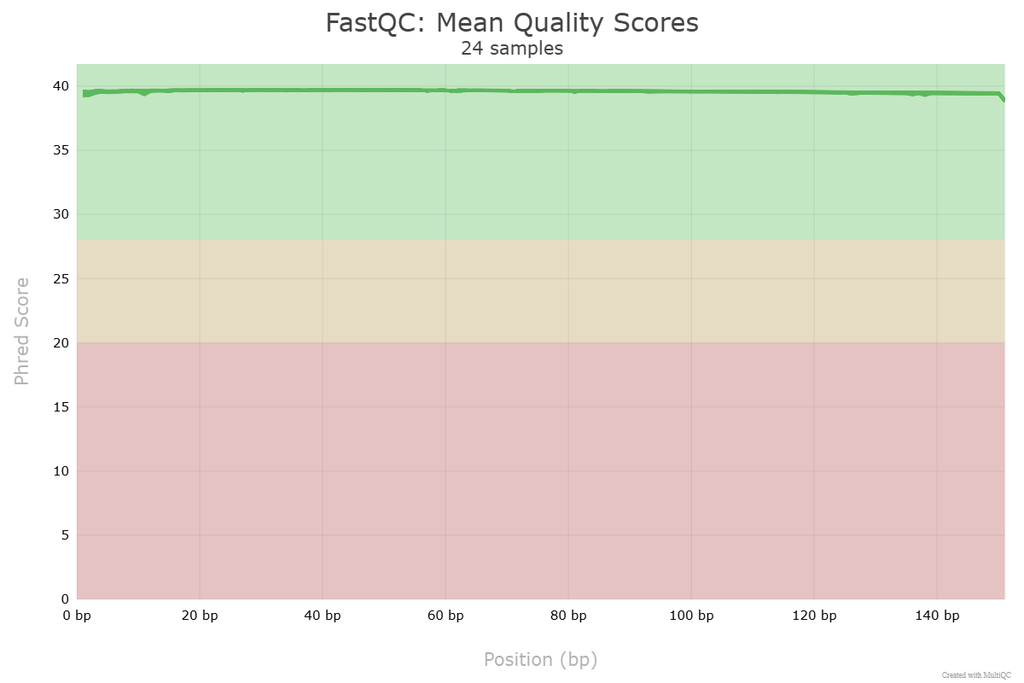

## Binning

To assign RNA-seq reads in each “mixture”/pool to the right species, we initially modified the contig names of each reference genome and gtf files so that they include the species name and can be combined in multi-species reference files that would be assigned to the corresponding pool. Then, we used the splice-aware STAR to find the best match using the following options:

```r
# #Step 4: Build STAR index for the sample-specific multi-species reference
# STAR --runMode genomeGenerate \
#          --runThreadN 4 \
#          --genomeDir ${sample}_star_index \
#          --genomeFastaFiles ${REFERENCE_FASTA_DIR}/${sample}_multispecies.fas \
#          --sjdbGTFfile ${REFERENCE_GTF_DIR}/${sample}_multispecies.gtf \
#          --genomeSAindexNbases 12 \
#          --sjdbOverhang 150
#
# #Step 5: Align reads with STAR and index output bam file
# STAR --genomeDir ${sample}_star_index \
#          --runThreadN 4 \
#          --readFilesIn ${FASTP_files_path}/${sample}_trimmed_1.fastq.gz ${FASTP_files_path}/${sample}_trimmed_2.fastq.gz \
#          --readFilesCommand zcat \
#          --outFilterMultimapNmax 999 \
#          --outFileNamePrefix STAR_BAM/${sample}_ \
#          --outSAMtype BAM SortedByCoordinate \
#          --outSAMattributes NH HI NM MD AS \
#          --outReadsUnmapped Fastx
# samtools index STAR_BAM/${sample}_Aligned.sortedByCoord.out.bam
```

We then split each species data in each resulting mapping file:

```r
#For the current sample,split BAM file per species and count reads per gene with featureCounts
# mkdir -p read_counts_summary
# for sp in $SPECIES; do
#         # Extract contig names for this species
#         grep "^>${sp}_" ${REFERENCE_FASTA_DIR}/${sample}_multispecies.fas | cut -d' ' -f1 | sed 's/>//' > ${sample}_${sp}_contigs.txt
#
#         # Extract alignments for this species
#         samtools view -b -o STAR_BAM/${sample}_${sp}.bam STAR_BAM/${sample}_Aligned.sortedByCoord.out.bam $(cat ${sample}_${sp}_contigs.txt)
#
#         # Count reads per gene using featureCounts
#         featureCounts -T 4 -p --countReadPairs -B -C -a ${REFERENCE_GTF_DIR}/${sample}_${sp}_modified.gtf -o read_counts_summary/${sample}_${sp}_counts.txt STAR_BAM/${sample}_${sp}.bam
# done
```

The resulting summary statistics show that we are losing 16.4% to 20.3% reads during pre-processing, which is too much as it could be provide enough data to reconstruct the transcriptome of multiple species:

[figure not shown]

The pre-processing arguments thus need to be adjusted to pooled RNA-seq. Fastp was probably not designed to perform pre-processing with a mixture of species RNA (different GC content, overrepresented sequenced are removed which might not always be good, etc) so a simpler pre-processing method like trimmomatics might be better.

After the binning, the samples from the same mixture seem to be more identical to each others compared to samples from other mixtures. However, there is a variation in the relative abundance of each species and few recurrent false-positives (contamination? mislabelling?). In general, at least 3 true-positive species are retrieved in each sample. The false negatives could be explained by reads removed during pre-processing, unmapped reads due to errors or bad quality in some reference genomes, mislabelling, etc.

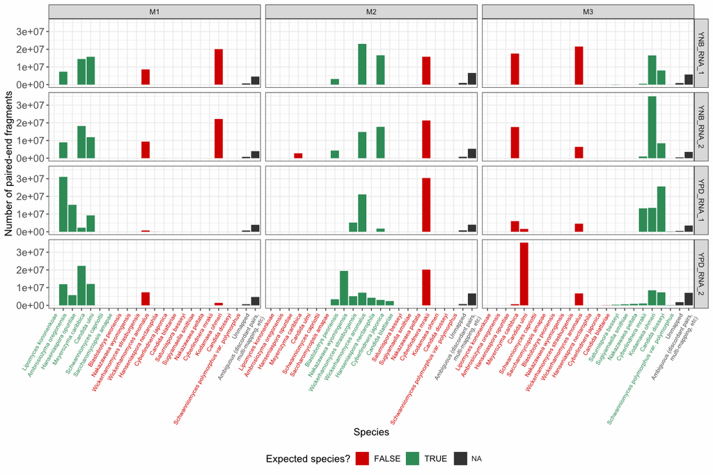

Finally, another weird observation is that when I try to perform a taxonomic profiling of the unmapped reads using a database with the 21 yeast species, CCMetagen (which uses kma instead of STAR) is able to map them to some of the yeast species (See example below). The way CCMetagen works is that it will only confidently assign a read to a species if the level of sequence identity is past a certain threshold. Otherwise, it is going to assign it at other taxonomic levels using other sequence identity thresholds (https://pmc-ncbi-nlm-nih-gov.myaccess.library.utoronto.ca/articles/PMC7189439/):

- Species: 97% - 100% sequence identity.
- Genus: 95% - 97% sequence identity.
- Family: 90% - 95% sequence identity.
- Order and higher: Thresholds become less reliable and are generally below 90%.

Here is an example for the M1_YNB_RNA_1 reads not mapped by STAR:

[figure not shown]

A caveat is that these alignments have huge “gaps” or indels so I am not sure what it means (chimeric reads, the reads come from other species, etc.). I observed the same taxonomic profiling even when I include all fungi sequences in ncbi-nt.